# Point Processes

## Question 1 - A bit of statistics with Poisson processes

We are observing two independent spike trains on the same interval $[0, T]$ and we want to test if their firing rate is the same. We will assume here that we have two independent Poisson processes $N^a$ and $N^b$ with rate $\lambda_a(.)$ and $\lambda_b(.)$, not necessarily constant.

**A** – What is the distribution of $N^a_T$ and $N^b_T$, respectively the number of points of $N^a$ and $N^b$ in $[0,T]$? Are these variables independent?

**B** – Compute $\mathbb{P}(N^a_T=k \cup N^b_T=l)$ for all $k$ and $l$.

**C** – Let $N_T= N^a_T+N^b_T$. Compute $\mathbb{P}(N_t=n)$ for all $n$. Can you give the name and the parameters of this distribution?

**D** – Compute $\mathbb{P}(N^a_t=k|N_t=n)$. *You can first see that $k$ has to be less than $n$ and that in this case $N^b_T = n-k$*. Can you give the name and the parameters of this conditional distribution?

**E** – Under the null hypothesis that $\lambda_a(.) = \lambda_b(.)$, realize that the previous distribution is known and derive from it a test of $H_0:\lambda_a(.)=\lambda_b(.)$ versus $H_1:\lambda_a(.)\ge\lambda_b(.)$

**F** – Apply it on the data of the STAR package for two different neurons. NB: *If $N^1, ..., N^n$ are IID Poisson processes with intensity $\lambda(.)$ then $N = N^1\cup ...\cup N^n$ is a Poisson process with rate $n\lambda(.)$. You can use that to glue all the trials together.*

### step A

Given that the two independent Poisson processes $N^a$ and $N^b$ don’t have necessarily constant rates $\lambda_a(.)$ and $\lambda_b(.)$, we can consider them inhomogeneous Poisson process over an interval $[0,T]$. As such, given the random variables $N^a_T$ and $N^b_T$ the number of points of $N^a$ and $N^b$ that happened in the interval $[0,T]$, we have:

$$\begin{align}
N^a_T&\sim\mathbb{P}\big(\int_{[0,T]}\lambda_a(x)dx\big)\\
N^b_T&\sim\mathbb{P}\big(\int_{[0,T]}\lambda_b(x)dx\big)\\
\text{Where}&,\\
\lambda_a&,\text{ the intensity of the process $a$}\\
\lambda_b&,\text{ the intensity of the process $b$}
\end{align}$$

Based on [wikipedia](https://en.wikipedia.org/wiki/Poisson_point_process)’s formulas, we can state the following:

$$\begin{align}
\Lambda_a(0, T)&=\int_{[0,T]}\lambda_a(x)dx\\
\Lambda_b(0, T)&=\int_{[0,T]}\lambda_b(x)dx\\
P(N^a_T=k)&=\frac{\big[\Lambda_a(0, T)\big]^k}{k!}.e^{-\Lambda_a(0, T)}\\
P(N^a_T=l)&=\frac{\big[\Lambda_b(0, T)\big]^l}{l!}.e^{-\Lambda_b(0, T)}
\end{align}$$

Given that the two Poisson processes $N^a$ and $N^b$ are independent, we can consider the random variables $N^a_T$ and $N^b_T$ to be independent as well.

### step B

Based on our independence hypothesis stated in step A, we can say that, for two random variable $X$ and $Y$ that $P(X\cup Y)=P(X).P(Y)$. As such:

$$\begin{align}
\mathbb{P}(N^a_T=k \cup N^b_T=l)&=\mathbb{P}(N^a_T=k) * \mathbb{P}(N^b_T=l)\\
&= \frac{\big[\Lambda_a(0, T)\big]^k}{k!}.e^{-\Lambda_a(0, T)} * \frac{\big[\Lambda_b(0, T)\big]^l}{l!}.e^{-\Lambda_b(0, T)}\\
&= \frac{\big[\Lambda_a(0, T)\big]^k\big[\Lambda_b(0, T)\big]^l}{k!l!}.e^{-(\Lambda_a(0, T)+\Lambda_b(0, T))}\\
&= \frac{\big[\Lambda_a(0, T)\big]^k\big[\Lambda_b(0, T)\big]^l}{k!l!}.e^{-(\int_{[0,T]}\lambda_a(x)+\lambda_b(x)dx)}
\end{align}$$

### step C

We previously found:

$$\begin{align}
\mathbb{P}(N^a_T=k \cup N^b_T=l)&= \frac{\big[\Lambda_a(0, T)\big]^k\big[\Lambda_b(0, T)\big]^l}{k!l!}.e^{-(\Lambda_a(0, T)+\Lambda_b(0, T))}\\
\end{align}$$

As such, we can state:

$$\begin{align}
\mathbb{P}(N^a_T+N^b_T=n)&=\mathbb{P}(N^a_T=k, N^b_T=n-k)\quad\forall n,k\in\mathbb{N} \text{ s.t. } n-k>=0\\
&=\binom{n}{k}\mathbb{P}(N^a_T=k \cup N^b_T=n-k)\\
&=\binom{n}{k}\frac{\big[\Lambda_a(0, T)\big]^k\big[\Lambda_b(0, T)\big]^{n-k}}{k!(n-k)!}.e^{-(\Lambda_a(0, T)+\Lambda_b(0, T))}\\
&=e^{-(\Lambda_a(0, T)+\Lambda_b(0, T))}.\binom{n}{k}\frac{\big[\Lambda_a(0, T)\big]^k\big[\Lambda_b(0, T)\big]^{n-k}}{k!(n-k)!}\\
\end{align}$$

Relying on the binomial formula, we can then state:

$$\begin{align}
\mathbb{P}(N^a_T+N^b_T=n)&=e^{-(\Lambda_a(0, T)+\Lambda_b(0, T))}.\frac{\big[\Lambda_a(0, T)+\Lambda_b(0, T)\big]^{n}}{n!}\\
\end{align}$$

As such, we find:

The sum of the random variables $N^a_T$ and $N^b_T$ also follows a Poisson distribution with parameter/rate $\Lambda_a(0, T)+\Lambda_b(0, T)$.

$$\begin{align}
N^a_T+N^b_T&\sim\mathbb{P}\big(\int_{[0,T]}\lambda_a(x)+\lambda_b(x)dx\big)\\
\end{align}$$

This can be verified with the Theorem 18.2 “Superposition of independent Poisson processes” (Source: [MAT135B: Stochastic Processes, complete lecture notes, Spring 2011, page 200](https://www.math.ucdavis.edu/~gravner/MAT135B/materials/)), reproduced here:

- *Assume that $N_1(t)$ and $N_2(t)$ are independent Poisson processes with rates $\lambda_1$ and $\lambda_2$. Combine them into a single process by taking the union of both sets of events or, equivalently, $N(t) = N_1(t) + N_2(t)$. This is a Poisson process with rate $\lambda_1 + \lambda_2$.*

### step D

We know that:

$$\begin{align}
P(X,Y)&=P(X).P(Y)\quad\text{when $X$ and $Y$ are independent}\\
P(X|Y)&=\frac{P(X,Y)}{P(Y)}
\end{align}$$

As such:

$$\begin{align}
\mathbb{P}(N^a_T=k|N_T=n)&=\frac{\mathbb{P}(N^a_T=k,N_T=n)}{\mathbb{P}(N_T=n)}\\
&=\frac{\mathbb{P}(N^a_T=k,N^a_T + N^b_T=n)}{\mathbb{P}(N^a_T + N^b_T=n)}\\
&=\frac{\mathbb{P}(N^a_T=k,N^b_T=n-k)}{e^{-(\Lambda_a(0, T)+\Lambda_b(0, T))}.\frac{\big[\Lambda_a(0, T)+\Lambda_b(0, T)\big]^{n}}{n!}}\\
&=\frac{\mathbb{P}(N^a_T=k).\mathbb{P}(N^b_T=n-k)}{e^{-(\Lambda_a(0, T)+\Lambda_b(0, T))}.\frac{\big[\Lambda_a(0, T)+\Lambda_b(0, T)\big]^{n}}{n!}}\\
&=\frac{\frac{\big[\Lambda_a(0, T)\big]^k}{k!}.e^{-\Lambda_a(0, T)}.\frac{\big[\Lambda_b(0, T)\big]^{n-k}}{(n-k)!}.e^{-\Lambda_b(0, T)}}{e^{-(\Lambda_a(0, T)+\Lambda_b(0, T))}.\frac{\big[\Lambda_a(0, T)+\Lambda_b(0, T)\big]^{n}}{n!}}\\
&=\frac{\frac{\big[\Lambda_a(0, T)\big]^k}{k!}.\frac{\big[\Lambda_b(0, T)\big]^{n-k}}{(n-k)!}}{\frac{\big[\Lambda_a(0, T)+\Lambda_b(0, T)\big]^{n}}{n!}}\\
&=\frac{n!\big[\Lambda_a(0, T)\big]^k.\big[\Lambda_b(0, T)\big]^{n-k}}{k!(n-k)!\big[\Lambda_a(0, T)+\Lambda_b(0, T)\big]^{n}}\\
&=\binom{n}{k}\frac{\big[\Lambda_a(0, T)\big]^k.\big[\Lambda_b(0, T)\big]^{n-k}}{\big[\Lambda_a(0, T)+\Lambda_b(0, T)\big]^{n}}\\
&=\binom{n}{k}\frac{\big[\Lambda_a(0, T)\big]^k.\big[\Lambda_b(0, T)\big]^{n-k}}{\underset{k'=0}{\overset{n}{\sum}}\binom{n}{k'}\Lambda_a(0, T)^{k'}\Lambda_b(0, T)^{n-k'}}\\
\end{align}$$

### step E

### step F

## Question 2 - Simulation

**A** – Simulate by thinning a Poisson process with intensity $t\rightarrow h(t) = (1-t^2)$ when $t\in[0,1]$ and $0$ elsewhere.

**B** – How many points should produce such a process in average? Verify it on you computer.

**C** – Simulate parents $T_p$ according to a Poisson process of rate $M$. Then for each parent simulate their children that have appeared after them according to a Poisson process with intensity $h(t-T_p)$.

**D** – Interpret this process as a particular case of Multivariate Hawkes process with 2 processes, for which you will give spontaneous parameters and intercation functions. Find another way to simulate this by success thinning. *NB: These algorithms are complex, try first to write it down on a sheet of paper before implementing them*

### step A

Overall, the intensity function decreases over the space $t\in[0, 1]$ as such:

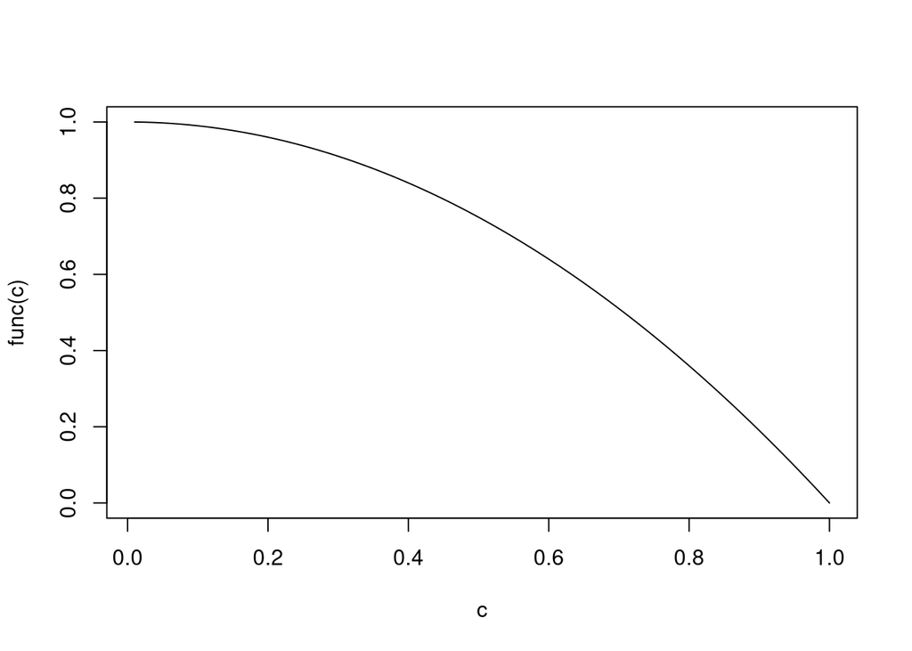

```r
func <- function(t){1-t^2}
c = seq(1,100,1)/100
plot(c, func(c), type="l")
```

Intuitively, we would expect the poisson process to not always output a single point as the intensity is a decreasing function of time.

So, given the intensity $h(t)=(1-t^2)$, we set $M=1$ as $\forall t\in [0, 1],\,h(t)<=1$. We produce the following thinning simulator:

```r
poisson_process_simulation_thinning <- function(){
  ### Simulate by thinning a Poisson process with intensity t->h(t)=(1−t2)
  ### when t∈[0,1] and 0 elsewhere.
  M = 1
  Tmax = 1
  func <- function(t){rbinom(1,1,1-t^2)}
  simulation = cumsum(rexp(100, M))
  simulation = matrix(simulation[simulation<=Tmax])
  if (length(simulation)==0) {
    return(NA)
  }
  ret = c()
  for (i in 1:length(simulation)){
    if (func(simulation[i])==1){
      ret = cbind(ret, simulation[i])
    }
  }
  if (length(ret)==0){
    return(NA)
  } else {
    ret[,!is.na(ret)]
  }
}
```

Then we compute 100 simulations of this thinning process as example:

```r
for (i in 1:100){
  cat("Simulation #", i, ": ", poisson_process_simulation_thinning(), "\n")
}
```

```
## Simulation # 1 :  NA
## Simulation # 2 :  0.512526
## Simulation # 3 :  NA
## Simulation # 4 :  NA
## Simulation # 5 :  NA
## Simulation # 6 :  0.3091014
## Simulation # 7 :  0.1587642 0.3220234
## Simulation # 8 :  0.4150293
## Simulation # 9 :  NA
## Simulation # 10 :  0.1581283
## Simulation # 11 :  NA
## Simulation # 12 :  NA
## Simulation # 13 :  NA
## Simulation # 14 :  NA
## Simulation # 15 :  NA
## Simulation # 16 :  NA
## Simulation # 17 :  NA
## Simulation # 18 :  0.3131523
## Simulation # 19 :  0.09821751 0.2213792 0.4034632
## Simulation # 20 :  NA
## Simulation # 21 :  0.4378178
## Simulation # 22 :  NA
## Simulation # 23 :  0.2329627 0.7118497
## Simulation # 24 :  NA
## Simulation # 25 :  0.3339395 0.707189
## Simulation # 26 :  NA
## Simulation # 27 :  NA
## Simulation # 28 :  0.02062077
## Simulation # 29 :  0.6401892
## Simulation # 30 :  0.703801
## Simulation # 31 :  NA
## Simulation # 32 :  NA
## Simulation # 33 :  0.04402161 0.3242936
## Simulation # 34 :  NA
## Simulation # 35 :  NA
## Simulation # 36 :  NA
## Simulation # 37 :  0.0206175
## Simulation # 38 :  0.9247167
## Simulation # 39 :  0.07232814 0.4277427
## Simulation # 40 :  0.5747515
```

[output cut: 45 more lines]

```
## Simulation # 86 :  NA
## Simulation # 87 :  0.5434755
## Simulation # 88 :  NA
## Simulation # 89 :  0.02652303
## Simulation # 90 :  0.06749315 0.1094435
## Simulation # 91 :  NA
## Simulation # 92 :  0.02457571 0.5971736
## Simulation # 93 :  NA
## Simulation # 94 :  0.08121827 0.2296393
## Simulation # 95 :  0.5689607 0.7226152
## Simulation # 96 :  NA
## Simulation # 97 :  0.7993624
## Simulation # 98 :  NA
## Simulation # 99 :  0.09278144 0.4079101 0.5343786
## Simulation # 100 :  NA
```

### step B

On average on $t\in[0,1]$, we have:

The average amount of created points should be $\frac{2}{3}$ over $t\in[0, 1]$. We can confirm this by going back to our simulation function and count the average number of generated points over the total number of simulations.

```r
count_nb_point_generated <- function(){
  ### Counts the number of generated points during 1000 poisson process simulation with thinning
  counter = 0
  for (i in 1:1000){
    simulation = poisson_process_simulation_thinning()
    if (length(simulation)==0 || !is.na(simulation)){counter = counter + length(simulation)}
  }
  return(list("nb"=counter, "rate"=counter/1000))
}

example = count_nb_point_generated()
cat("Example -- ", example$nb, " points were generated over 1000 simulations, i.e. a rate of ", example$rate, ".")
```

```
## Example --  669  points were generated over 1000 simulations, i.e. a rate of  0.669 .
```

We plot out the empirical distribution of the simulated rate after 1000 batches of 1000 simulations with, in red, the previously computed expected average number of generated points.

```r
distribution_of_counter = apply(matrix(c(1:1000)), 1, function(x){count_nb_point_generated()$rate})
cat("Mean rate obtained after 1000 batches of 1000 simulations", mean(distribution_of_counter))
```

```
## Mean rate obtained after 1000 batches of 1000 simulations 0.666034
```

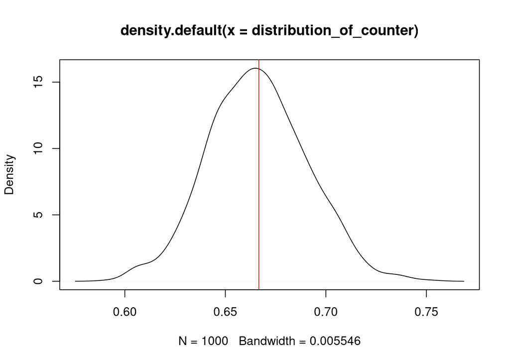

```r
plot(density(distribution_of_counter))
abline(v=2/3, col="red")
```

Our empirical observation seems to match our mathematical computation.

### step C

### step D